# Flores et al

Sasha Mikheyev

8/10/2020

```r
library(tidyverse) # various useful R enhancenents
library(readxl) # for reading excel files
library(bipartite) # for network tools
```

## Flores et al

Read raw data from the excel file. There are separate sheets for each experiment, and we load all of them into a list, where each element is a matrix.

```r
studies <- excel_sheets("data/sd02.xls")
phageDat <- lapply(studies, function(x) read_excel("data/sd02.xls", sheet = x))
```

[output not shown]

[output not shown]

[output not shown]

[output not shown]

[output not shown]

[output not shown]

[output not shown]

[output not shown]

[output not shown]

[output not shown]

[output not shown]

[output not shown]

[output not shown]

[output not shown]

[output not shown]

[output not shown]

[output not shown]

[output not shown]

[output not shown]

[output not shown]

[output not shown]

[output not shown]

[output not shown]

[output not shown]

```r
names(phageDat) <- studies
```

## Getting started

- What was indixes were analyzed in the original paper?

The details of the methods are in the [online supplement](https://www.pnas.org/content/pnas/suppl/2011/06/24/1101595108.DCSupplemental/sapp.pdf). - They used the Q metric

## Examining nestedness in the data set

- Note: I’m using 100 permutations for speed, in reality you would want something like 1000.
- To speed things up I pre-computed a couple of the variables.

```r
if (file.exists("nulls.Rdata")) {
  nulls <- readRDS("nulls.RData")
} else {
  nulls <- lapply(phageDat, function(x) nullmodel(x, N=100, method="shuffle.web"))
  saveRDS(nulls, "nulls.RData")
}

nestednessObs <- sapply(phageDat, function(x) networklevel(x, index="nestedness"))

if (file.exists("nestednessNulls.Rdata")) {
  nestednessNulls <- readRDS("nestednessNulls.RData")
} else {
  nestednessNulls <- pbapply::pblapply(nulls, function (x) sapply(x, function(y) networklevel(y, index="nestedness")))
  saveRDS(nestednessNulls, "nestednessNulls.RData")
}
```

## Examining output

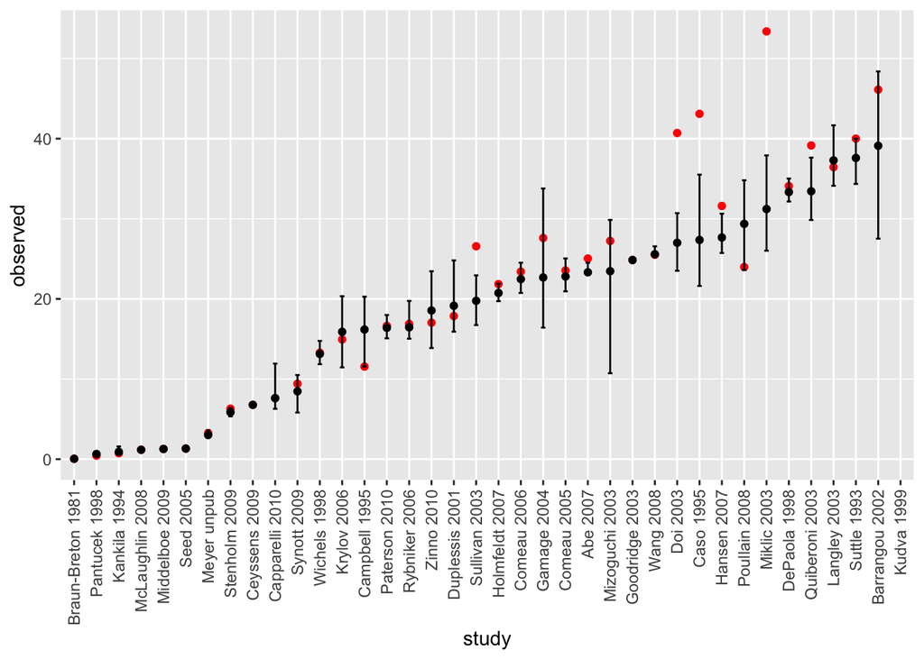

```r
nestednessDat <- data.frame(mean = sapply(nestednessNulls, function(x) mean(x)),
           lower = sapply(nestednessNulls, function(x) quantile(x, 0.025, na.rm = T)),
           upper = sapply(nestednessNulls, function(x) quantile(x, 0.975, na.rm = T)),
           observed = nestednessObs,
           study = studies)
nestednessDat$study <- factor(nestednessDat$study, levels = studies[order(nestednessDat$mean)])

ggplot(nestednessDat, aes(x = study, y = observed)) + geom_point(color = "red") + geom_point(aes(y = mean), color = "black") + geom_errorbar(aes(ymin = lower, ymax = upper, width = 0.2)) + theme(axis.text.x = element_text(angle = 90, vjust = 0.5, hjust=1))
```

## Homework

- Recreate Fig. 6A.
- According to Delmas et al NODF is currently the most commonly used nestedness measure
- Do you get the same results if you use a different network permutation approach? Here I used the `shuffle.web` algorithm, but `mgen` should also work for binary networks. You can find more information about there algorithms by examining the function documentation, e.g., `?shuffle.web`
- Do we need addtional null models for our study?